# Zaderenko 07

7 actividades; sólo se conoce el Gantt de inicios tempranos

# Enunciado

De un proyecto sólo se conserva su programación de inicios más tempranos: la semana en que empieza cada actividad y su duración (cuadro adjunto). Se sabe que el calendario se calculó correctamente a partir de un cuadro de prelaciones que se ha perdido.

1. Dibuje el diagrama de Gantt y calcule el fin más temprano de cada actividad y la duración del proyecto.

2. ¿Qué actividades son iniciales? Para cada una de las demás, ¿qué actividades *pueden* ser predecesoras inmediatas suyas (terminan no más tarde de su inicio) y cuáles son las «ajustadas» (terminan exactamente cuando ella empieza)? ¿Por qué toda actividad no inicial tiene al menos una predecesora ajustada?

3. Encadenando actividades ajustadas desde la semana 0 hasta el final, identifique una ruta crítica. ¿Puede haber más de una?

4. Se recupera el cuadro de prelaciones original. Compruebe que es compatible con el Gantt y compare sus prelaciones con las predecesoras ajustadas deducidas.

Tabla 1: Cuadro de datos del enunciado

| activity | start | duration |
| --- | --- | --- |
| A | 0 | 5 |
| B | 0 | 8 |
| C | 8 | 3 |
| D | 11 | 1 |
| E | 11 | 2 |
| F | 13 | 5 |
| G | 18 | 4 |

El proyecto corresponde al lanzamiento de una aplicación móvil; las actividades son las siguientes (las duraciones del cuadro están en semanas).

Tabla 2: Descripción de las actividades

|  | Descripción |
| --- | --- |
| A | Estudio de requisitos |
| B | Diseño de la arquitectura |
| C | Diseño de interfaz y prototipo |
| D | Base de datos y modelo |
| E | API del servidor |
| F | Pantallas principales |
| G | Módulo de pagos |

# Resolución

## Apartado 1

1. Dibuje el diagrama de Gantt y calcule el fin más temprano de cada actividad y la duración del proyecto.

| activity | start | duration | end |
| --- | --- | --- | --- |
| A | 0 | 5 | 5 |
| B | 0 | 8 | 8 |
| C | 8 | 3 | 11 |
| D | 11 | 1 | 12 |
| E | 11 | 2 | 13 |
| F | 13 | 5 | 18 |
| G | 18 | 4 | 22 |

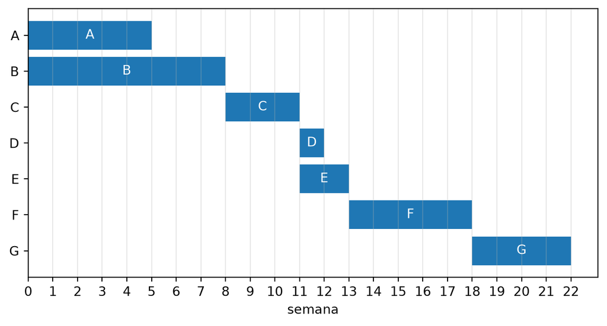

Figura 1: Diagrama de Gantt de la programación conservada

La duración del proyecto es el mayor fin: 22 semanas.

## Apartado 2

2. ¿Qué actividades son iniciales? Para cada una de las demás, ¿qué actividades *pueden* ser predecesoras inmediatas suyas (terminan no más tarde de su inicio) y cuáles son las «ajustadas» (terminan exactamente cuando ella empieza)? ¿Por qué toda actividad no inicial tiene al menos una predecesora ajustada?

Una actividad que empieza en la semana 0 es inicial. Si $P$ terminara después de que empiece $A$, $P$ no podría ser predecesora de $A$. En un calendario de inicios más tempranos, el inicio de cada actividad no inicial es el *máximo* de los fines de sus predecesoras, luego alguna de ellas termina exactamente cuando la actividad empieza.

```
Iniciales: A, B
```

|  | posibles predecesoras | ajustadas (fin = inicio) |
| --- | --- | --- |
| A | — | — |
| B | — | — |
| C | A, B | B |
| D | A, B, C | C |
| E | A, B, C | C |
| F | A, B, C, D, E | E |
| G | A, B, C, D, E, F | F |

## Apartado 3

3. Encadenando actividades ajustadas desde la semana 0 hasta el final, identifique una ruta crítica. ¿Puede haber más de una?

```
B - C - E - F - G = 8 + 3 + 2 + 5 + 4 = 22
```

Se deducen 1 cadena(s) ajustada(s) de la semana 0 al final: cada una es una ruta crítica *si* todas sus prelaciones consecutivas existen en el cuadro perdido; puede haber más de una.

## Apartado 4

4. Se recupera el cuadro de prelaciones original. Compruebe que es compatible con el Gantt y compare sus prelaciones con las predecesoras ajustadas deducidas.

Tabla 3: Cuadro de prelaciones recuperado

| activity | predecessor | duration |
| --- | --- | --- |
| A | --- | 5 |
| B | --- | 8 |
| C | A,B | 3 |
| D | C | 1 |
| E | C | 2 |
| F | E | 5 |
| G | D,F | 4 |

|  | predecesoras reales | ajustadas deducidas | ajustadas que son antecesoras | ajustadas por coincidencia |
| --- | --- | --- | --- | --- |
| A | — | — | — | — |
| B | — | — | — | — |
| C | A, B | B | B | — |
| D | C | C | C | — |
| E | C | C | C | — |
| F | E | E | E | — |
| G | D, F | F | F | — |

El cuadro recuperado reproduce el Gantt: True. Una predecesora ajustada suele ser una antecesora real (inmediata o no), pero puede ser una coincidencia de fechas; y las predecesoras reales con holgura entre su fin y el inicio de la sucesora no se ven en el Gantt. Por eso el Gantt no determina el cuadro de prelaciones.

Cálculo de los tiempos tempranos y tardíos de los sucesos y de las holguras totales paso a paso. El primer paso muestra el grafo resuelto; a partir del siguiente se calcula desde el principio (avance con los botones):

paso 0 de 24

[figure not shown]

Figura 2: Grafo PERT con el camino crítico